# 08_QuantLing_Section

Eric Wilbanks

3/13/2020 - 3/16/2020

## 1. Goals for Section

1. Midterm-Evals Summary
2. Linear Models - Requested Topics
3. Logistic Regression - Overview

## 2. Midterm-Evals Summary

Thanks for filling out the evals! Here’s a summary of the responses to some key points:

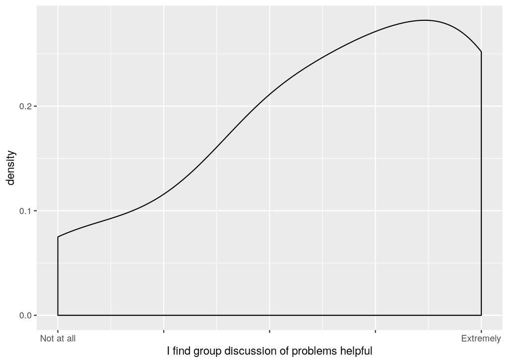

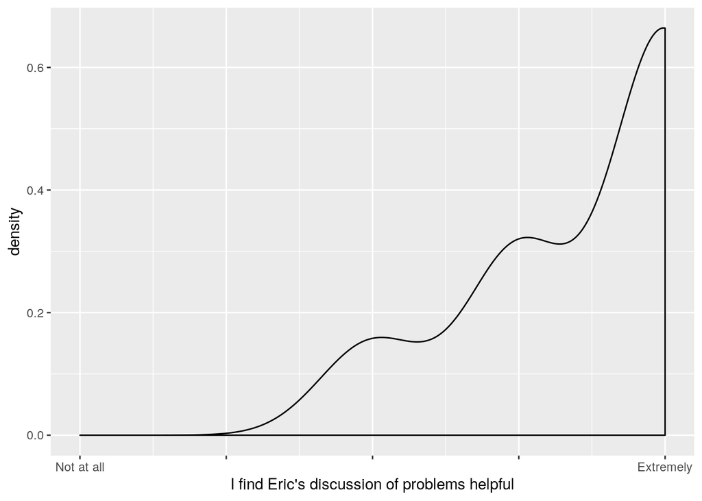

*Looking at your preferences, I’ll still keep group discussions in, but try to incorporate a little bit more of me summarizing key concepts*

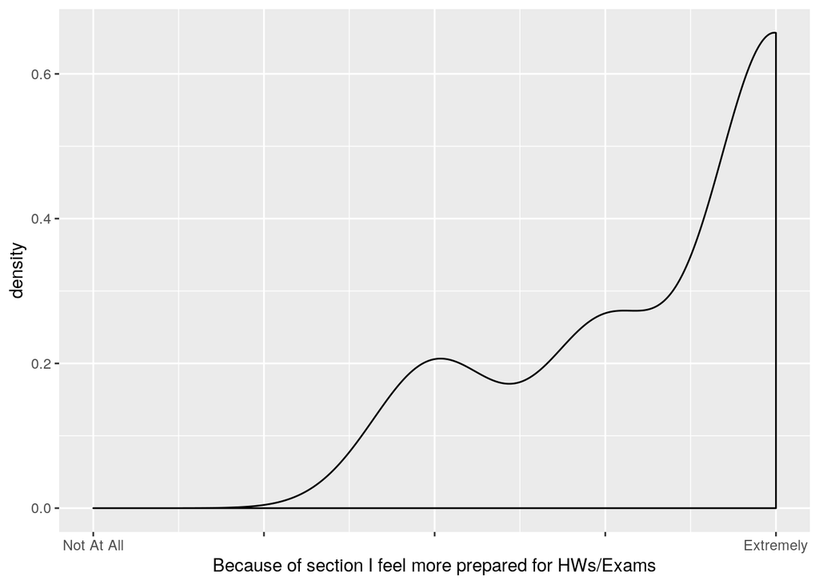

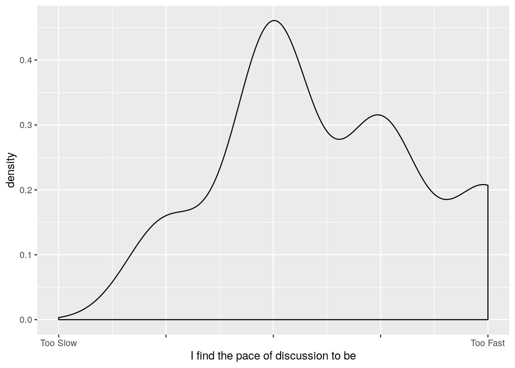

*I’m glad you all feel on average more prepared! For the pace of section, I’ll try slowing down a bit [though not too much! the median is about “just right”]

## 3. Linear Regression Requested Topics

Some of the most-requested topics for linear modeling were:

1. Multi-level Categorical Predictors
2. Interactions
3. Comparing Model Fit

### 3a. Chick Weight Measurements

Let’s get some more practice with these types of models using a dataset already in R about how the weight of Chicks changes over time and on different diets.

```r
library(ggplot2)
library(lme4)
data(ChickWeight)
summary(ChickWeight)
```

```
##      weight           Time           Chick     Diet
##  Min.   : 35.0   Min.   : 0.00   13     : 12   1:220
##  1st Qu.: 63.0   1st Qu.: 4.00   9      : 12   2:120
##  Median :103.0   Median :10.00   20     : 12   3:120
##  Mean   :121.8   Mean   :10.72   10     : 12   4:118
##  3rd Qu.:163.8   3rd Qu.:16.00   17     : 12
##  Max.   :373.0   Max.   :21.00   19     : 12
##                                  (Other):506
```

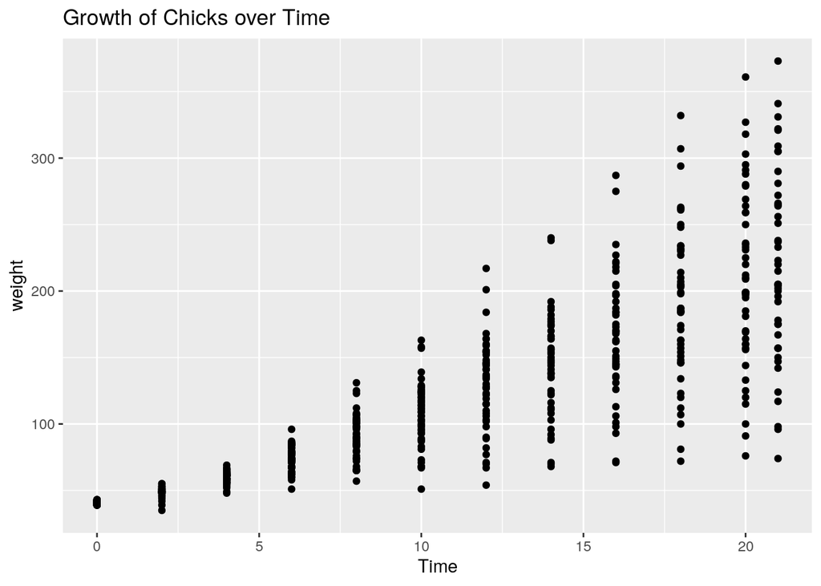

```r
ggplot(ChickWeight, aes(Time,weight)) + geom_point() + labs(title='Growth of Chicks over Time')
```

Let’s build the simplest linear model and work our way up to a full understanding.

```r
m1 <- lm(weight ~ Time, ChickWeight)
summary(m1)
```

```
##
## Call:
## lm(formula = weight ~ Time, data = ChickWeight)
##
## Residuals:
##      Min       1Q   Median       3Q      Max
## -138.331  -14.536    0.926   13.533  160.669
##
## Coefficients:
##             Estimate Std. Error t value Pr(>|t|)
## (Intercept)  27.4674     3.0365   9.046   <2e-16 ***
## Time          8.8030     0.2397  36.725   <2e-16 ***
## ---
## Signif. codes:  0 '***' 0.001 '**' 0.01 '*' 0.05 '.' 0.1 ' ' 1
##
## Residual standard error: 38.91 on 576 degrees of freedom
## Multiple R-squared:  0.7007, Adjusted R-squared:  0.7002
## F-statistic:  1349 on 1 and 576 DF,  p-value: < 2.2e-16
```

```r
# directly access the coefficients
m1$coefficients
```

```
## (Intercept)        Time
##   27.467425    8.803039
```

```r
# save them to separate variables
m1_int <- m1$coefficients[1]
m1_slope_time <- m1$coefficients[2]
```

We can then directly use these coefficients to plot the linear model we’ve fit on top of the raw data.

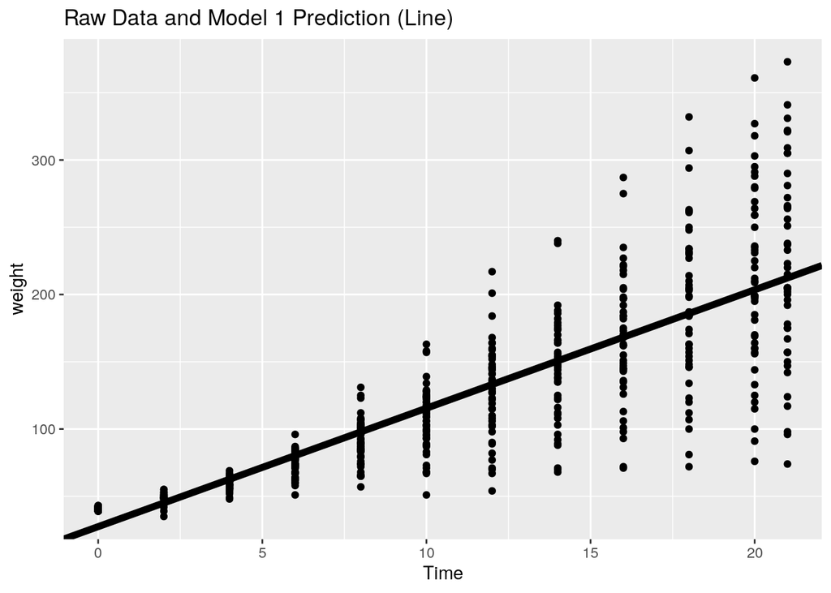

```r
ggplot(ChickWeight, aes(Time,weight)) + geom_point() + geom_abline(intercept = m1_int, slope = m1_slope_time, size=2) + labs(title="Raw Data and Model 1 Prediction (Line)")
```

### 3b. Multi-level Categorical Predictors

We saw that we have a clear positive effect of Time on weight (Chicks gain weight as they grow), but we want to test what possible effects on weight each type of diet has. Recall that the Diet predictor is categorical, with 4 levels.

```r
summary(ChickWeight$Diet)
```

```
##   1   2   3   4
## 220 120 120 118
```

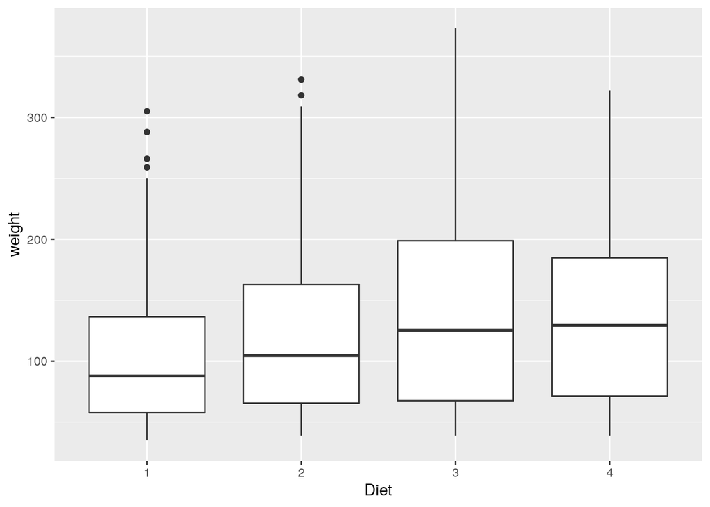

```r
ggplot(ChickWeight, aes(Diet, weight)) + geom_boxplot()
```

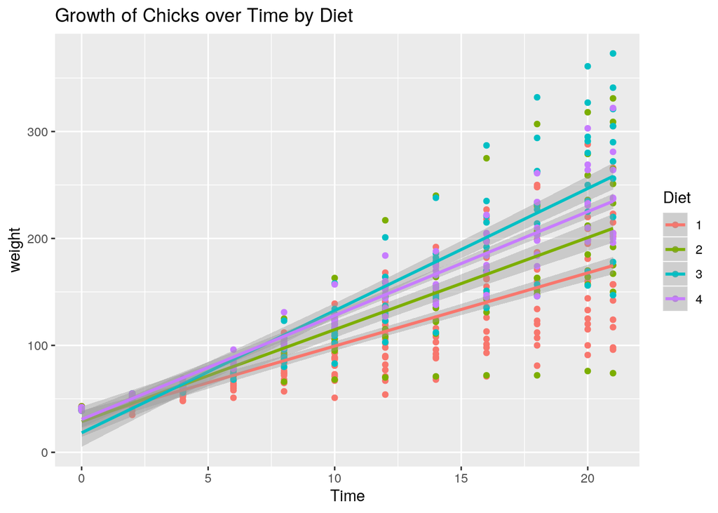

```r
ggplot(ChickWeight, aes(Time, weight, color=Diet)) + geom_point() + geom_smooth(method='lm') + labs(title='Growth of Chicks over Time by Diet')
```

Let’s create m2, which has this additional predictor.

```r
m2 <- lm(weight ~ Time + Diet, ChickWeight)
summary(m2)
```

```
##
## Call:
## lm(formula = weight ~ Time + Diet, data = ChickWeight)
##
## Residuals:
##      Min       1Q   Median       3Q      Max
## -136.851  -17.151   -2.595   15.033  141.816
##
## Coefficients:
##             Estimate Std. Error t value Pr(>|t|)
## (Intercept)  10.9244     3.3607   3.251  0.00122 **
## Time          8.7505     0.2218  39.451  < 2e-16 ***
## Diet2        16.1661     4.0858   3.957 8.56e-05 ***
## Diet3        36.4994     4.0858   8.933  < 2e-16 ***
## Diet4        30.2335     4.1075   7.361 6.39e-13 ***
## ---
## Signif. codes:  0 '***' 0.001 '**' 0.01 '*' 0.05 '.' 0.1 ' ' 1
##
## Residual standard error: 35.99 on 573 degrees of freedom
## Multiple R-squared:  0.7453, Adjusted R-squared:  0.7435
## F-statistic: 419.2 on 4 and 573 DF,  p-value: < 2.2e-16
```

Recall that **the interpretation of the Intercept is when all predictors are set to 0 or their reference level**. The reference level for Diet is “1”, and we only have estimates for the differences for each other level of Diet to level “1”.

Looking at the model coefficients, we have linear equations for 4 different lines: one for each Diet. Their exact values are:

1. Diet_1: (10.9243911) + (Time * 8.7504917)
2. Diet_2: (10.9243911 + 16.166074) + (Time * 8.7504917)
3. Diet_3: (10.9243911 + 36.4994074) + (Time * 8.7504917)
4. Diet_4: (10.9243911 + 30.2334562) + (Time * 8.7504917)

We can plot these four lines over the raw data. Pay special attention to comparing this plot with the plot of m1’s line.

```r
# estimate of time coefficient
time_slope <- m2$coefficients[2]

# adjustments to intercept by coefficients for categorical variable
d1_int <- m2$coefficients[1]
d2_int <- d1_int + m2$coefficients[3]
d3_int <- d1_int + m2$coefficients[4]
d4_int <- d1_int + m2$coefficients[5]

cat(c(d1_int,d2_int,d3_int,d4_int))
```

```
## 10.92439 27.09047 47.4238 41.15785
```

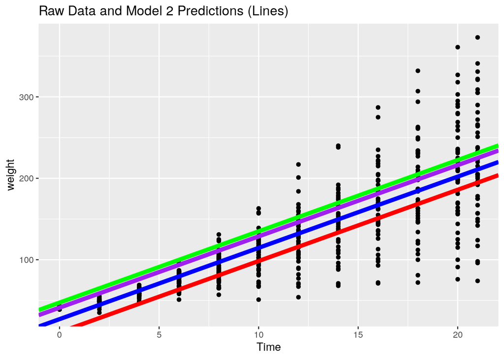

```r
# plot each line over raw data
ggplot(ChickWeight, aes(Time,weight)) + geom_point() + labs(title="Raw Data and Model 2 Predictions (Lines)") +
    geom_abline(intercept = d1_int, slope = time_slope, color='red', size=2) +
    geom_abline(intercept = d2_int, slope = time_slope, color='blue', size=2) +
    geom_abline(intercept = d3_int, slope = time_slope, color='green', size=2) +
    geom_abline(intercept = d4_int, slope = time_slope, color='purple', size=2)
```

We can notice that the intercepts have been adjusted for each diet (this is what the categorical estimate **is**, an adjustment of the intercept from the reference level).

One issue, though, is that our 4 lines are making incorrect predictions for **Time = 0**. That is, we expect chicks to start at the same weight at Time = 0, but to have a slower or faster growth rate on different diets.

**We want the slope of the Time line to be able to be different for different Diets**.

**This is an interaction term**

### 3c. Interactions

We want our estimated lines to be able to have different slopes for Time, depending on which Diet the chick was on. Let’s build a model that has this interaction term.

```r
m3 <- lm(weight ~ Time * Diet, ChickWeight)
summary(m3)
```

```
##
## Call:
## lm(formula = weight ~ Time * Diet, data = ChickWeight)
##
## Residuals:
##      Min       1Q   Median       3Q      Max
## -135.425  -13.757   -1.311   11.069  130.391
##
## Coefficients:
##             Estimate Std. Error t value Pr(>|t|)
## (Intercept)  30.9310     4.2468   7.283 1.09e-12 ***
## Time          6.8418     0.3408  20.076  < 2e-16 ***
## Diet2        -2.2974     7.2672  -0.316  0.75202
## Diet3       -12.6807     7.2672  -1.745  0.08154 .
## Diet4        -0.1389     7.2865  -0.019  0.98480
## Time:Diet2    1.7673     0.5717   3.092  0.00209 **
## Time:Diet3    4.5811     0.5717   8.014 6.33e-15 ***
## Time:Diet4    2.8726     0.5781   4.969 8.92e-07 ***
## ---
## Signif. codes:  0 '***' 0.001 '**' 0.01 '*' 0.05 '.' 0.1 ' ' 1
##
## Residual standard error: 34.07 on 570 degrees of freedom
## Multiple R-squared:  0.773,  Adjusted R-squared:  0.7702
## F-statistic: 277.3 on 7 and 570 DF,  p-value: < 2.2e-16
```

**Notice a few changes**:

**This is good!** We expected all of the Diets to have the same value of Weight when Time = 0 (the intercept), because they hadn’t started eating yet! We see no significant adjustment to the intercepts of each Diet (when we allow for adjustments to the slope).

**Also**,

1. The time coefficient is now a bit lower than it has been previously (m1 - 8.8, m2 - 8.75, m3 - 6.8).
2. This is because this is now the estimate for the slope of Time when Diet is at its reference level.
3. Each Interaction Term (Time:Diet2, Time:Diet3, and Time:Diet4) are **adjustments to the slope of Time for Diet 1**

**The formulas for each line are as follows:**

1. Diet_1: (30.9309803) + (Time * (6.8417972))
2. Diet_2: (30.9309803 + -2.2973848) + (Time * (6.8417972 + 1.7673391))
3. Diet_3: (30.9309803 + -12.6806551) + (Time * (6.8417972 + 4.5810738))
4. Diet_4: (30.9309803 + -0.1388608) + (Time * (6.8417972 + 2.8725684))

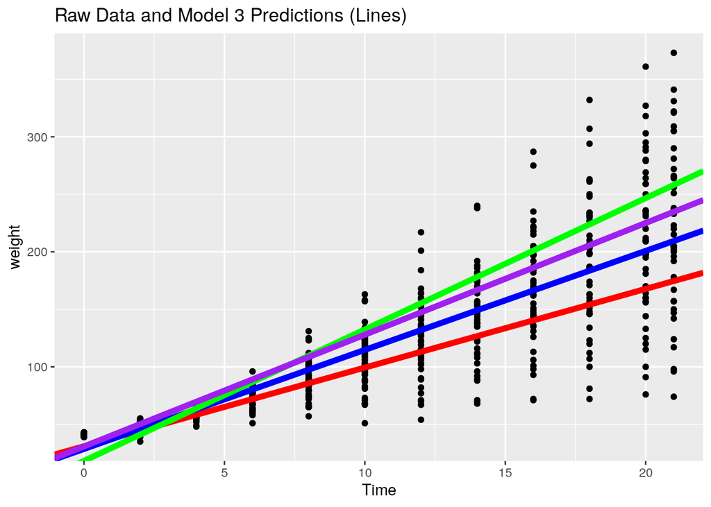

```r
# estimate of time coefficient
d1_slope <- m3$coefficients[2]
d2_slope <- d1_slope + m3$coefficients[6]
d3_slope <- d1_slope + m3$coefficients[7]
d4_slope <- d1_slope + m3$coefficients[8]

# adjustments to intercept by coefficients for categorical variable
d1_int <- m3$coefficients[1]
d2_int <- d1_int + m3$coefficients[3]
d3_int <- d1_int + m3$coefficients[4]
d4_int <- d1_int + m3$coefficients[5]

# plot each line over raw data
ggplot(ChickWeight, aes(Time,weight)) + geom_point() + labs(title="Raw Data and Model 3 Predictions (Lines)") +
    geom_abline(intercept = d1_int, slope = d1_slope, color='red', size=2) +
    geom_abline(intercept = d2_int, slope = d2_slope, color='blue', size=2) +
    geom_abline(intercept = d3_int, slope = d3_slope, color='green', size=2) +
    geom_abline(intercept = d4_int, slope = d4_slope, color='purple', size=2)
```

### 3d. Comparing Model Fit

One way to compare model fits is with the F-test (see lec10 for more details). The null-hypothesis of this test is that adding additional predictors **does not improve model fit**.

```r
anova(m1,m2)
```

```
## Analysis of Variance Table
##
## Model 1: weight ~ Time
## Model 2: weight ~ Time + Diet
##   Res.Df    RSS Df Sum of Sq      F    Pr(>F)
## 1    576 872212
## 2    573 742336  3    129876 33.417 < 2.2e-16 ***
## ---
## Signif. codes:  0 '***' 0.001 '**' 0.01 '*' 0.05 '.' 0.1 ' ' 1
```

```r
anova(m2,m3)
```

```
## Analysis of Variance Table
##
## Model 1: weight ~ Time + Diet
## Model 2: weight ~ Time * Diet
##   Res.Df    RSS Df Sum of Sq      F    Pr(>F)
## 1    573 742336
## 2    570 661532  3     80804 23.208 3.474e-14 ***
## ---
## Signif. codes:  0 '***' 0.001 '**' 0.01 '*' 0.05 '.' 0.1 ' ' 1
```

In comparing m1 and m2, we can reject the null hypothesis that model fit wasn’t improved, and choose m2 as the better model.

The same outcome happens comparing m2 and m3, so we choose m3 as our best model.

```r
AIC(m1,m2,m3)
```

```
##    df      AIC
## m1  3 5876.799
## m2  6 5789.607
## m3  9 5728.997
```

```r
BIC(m1,m2,m3)
```

```
##    df      BIC
## m1  3 5889.877
## m2  6 5815.765
## m3  9 5768.233
```

Unlike the F-test, AIC and BIC can be used on non-nested models. For AIC and BIC, the best model has the lowest value. In this case, both Information Criteria agree: **m3 is the best model**.

## 4. Logistic Regression

### 4a. Brief Overview

**Reminder** from Prof. Zymet:

“for logistic regression focus on what the model is generally supposed to do (i.e., predict binary outcomes), model output interpretation, and generating predictions. You won’t need to memorize the math of the logistic regression model. The review questions in lecture 14 are perfect for this.”

**Goal**:

- model binary outcomes (instead of continuous, like linear)

**How we get there (High-Level)**:

1. map probabilty of binary outcomes into log-odds ratio (logit function)
2. take inverse-logit to convert log-odds into probabilities
1. $logit(P(Y = 1)) = \beta_0 + \beta_1 *X_1$
2. $P(Y=1) = invlogit(\beta_0 + \beta_1 *X_1) = \frac{1}{1 + e^{-(\beta_0 + \beta_1*X)}}$

**Logistic Model Output**:

1. The estimates for logistic models are in logit space (log-odds ratio)
2. To convert them into probabilities, use the inverse-logit function (manually or using the `invlogit()` function from the `arm` package)

### 4b. Warlpiri Case

Let’s look at data from Warlpiri, a language of Northern Australia. The dependent variable is `warlpiri$CaseMarking` : a binary variable of either “ergative” or “other”. For non-linguists, this is basically a different form of the noun depending on its role in the sentence structure.

The predictor variables we’ll be investigating are `warlpiri$AgeGroup` (if the speaker was an adult or a child) and `warlpiri$AnimacyOfSubject` (whether the noun in question was an animate (living) creature or an inanimate object).

```r
library(arm)
library(languageR)
data(warlpiri)

w1 <- glm(CaseMarking ~ AgeGroup + AnimacyOfSubject, family='binomial', warlpiri)
summary(w1)
```

```
##
## Call:
## glm(formula = CaseMarking ~ AgeGroup + AnimacyOfSubject, family = "binomial",
##     data = warlpiri)
##
## Deviance Residuals:
##     Min       1Q   Median       3Q      Max
## -0.8725  -0.6315  -0.4621  -0.4621   2.1400
##
## Coefficients:
##                           Estimate Std. Error z value Pr(>|z|)
## (Intercept)                -2.1830     0.2465  -8.855   <2e-16 ***
## AgeGroupchild               0.6721     0.3017   2.228   0.0259 *
## AnimacyOfSubjectinanimate   0.7413     0.3396   2.183   0.0290 *
## ---
## Signif. codes:  0 '***' 0.001 '**' 0.01 '*' 0.05 '.' 0.1 ' ' 1
##
## (Dispersion parameter for binomial family taken to be 1)
##
##     Null deviance: 303.40  on 346  degrees of freedom
## Residual deviance: 293.86  on 344  degrees of freedom
## AIC: 299.86
##
## Number of Fisher Scoring iterations: 4
```

The interpretation of coefficient estimates is similar to linear models, but they are **changes to logit space (log-odds)** not just linear increases in y.

Here are the calculations of log-odds for each combination of Age and SubjectAnimacy:

1. Adult/Animate = (-2.1830311)
2. Adult/Inanimate = (-2.1830311) + (0.7413021) = -1.441729
3. Child/Animate = (-2.1830311) + (0.6720654) = -1.5109657
4. Child/Inanimate = (-2.1830311) + (0.6720654) + (0.7413021) = -0.7696636

And their calculations in probability space, using the `invlogit()` function:

```r
# Adult Animate Log Odds
aa_lo = w1$coefficients[1]
# Convert to Probability of "other Case" using inverse-logit
invlogit(aa_lo)
```

```
## (Intercept)
##   0.1012847
```

```r
# Adult Inanimate Log Odds
ai_lo = w1$coefficients[1] + w1$coefficients[3]
# Convert to Probability of "other Case" using inverse-logit
invlogit(ai_lo)
```

```
## (Intercept)
##   0.1912777
```

```r
# Child Animate Log Odds
ca_lo = w1$coefficients[1] + w1$coefficients[2]
# Convert to Probability of "other Case" using inverse-logit
invlogit(ca_lo)
```

```
## (Intercept)
##   0.1807957
```

```r
# Child Inanimate Log Odds
ci_lo = w1$coefficients[1] + w1$coefficients[2] + w1$coefficients[3]
# Convert to Probability of "other Case" using inverse-logit
invlogit(ci_lo)
```

```
## (Intercept)
##   0.3165519
```